# Homework assignment 1

Data Science and Machine Learning 2 - CEU 2018

Peter Paziczki

2018 március 15

```r
library(data.table)
library(caret)
```

```r
library(rpart)
library(rpart.plot)
library(xgboost)
library(randomForest)
library(gbm)
library(ISLR)
library(skimr) # for skim function
library(ROCR)
```

## 1. Classification tree model

In this problem I am going to work with the OJ dataset from the ISLR package. This dataset records purchases of two types of orange juices and presents customer and product characteristics as features. My goal is to predict which of the juices is chosen in a given purchase situation.

Loading the data set and having additional information about the it, variabe types. means of variables:

```r
data <- data.table(OJ)

#'?ISLR::OJ
str(data)
```

```
## Classes 'data.table' and 'data.frame':   1070 obs. of  18 variables:
##  $ Purchase      : Factor w/ 2 levels "CH","MM": 1 1 1 2 1 1 1 1 1 1 ...
##  $ WeekofPurchase: num  237 239 245 227 228 230 232 234 235 238 ...
##  $ StoreID       : num  1 1 1 1 7 7 7 7 7 7 ...
##  $ PriceCH       : num  1.75 1.75 1.86 1.69 1.69 1.69 1.69 1.75 1.75 1.75 ...
##  $ PriceMM       : num  1.99 1.99 2.09 1.69 1.69 1.99 1.99 1.99 1.99 1.99 ...
##  $ DiscCH        : num  0 0 0.17 0 0 0 0 0 0 0 ...
##  $ DiscMM        : num  0 0.3 0 0 0 0 0.4 0.4 0.4 0.4 ...
##  $ SpecialCH     : num  0 0 0 0 0 0 1 1 0 0 ...
##  $ SpecialMM     : num  0 1 0 0 0 1 1 0 0 0 ...
##  $ LoyalCH       : num  0.5 0.6 0.68 0.4 0.957 ...
##  $ SalePriceMM   : num  1.99 1.69 2.09 1.69 1.69 1.99 1.59 1.59 1.59 1.59 ...
##  $ SalePriceCH   : num  1.75 1.75 1.69 1.69 1.69 1.69 1.69 1.75 1.75 1.75 ...
##  $ PriceDiff     : num  0.24 -0.06 0.4 0 0 0.3 -0.1 -0.16 -0.16 -0.16 ...
##  $ Store7        : Factor w/ 2 levels "No","Yes": 1 1 1 1 2 2 2 2 2 2 ...
##  $ PctDiscMM     : num  0 0.151 0 0 0 ...
##  $ PctDiscCH     : num  0 0 0.0914 0 0 ...
##  $ ListPriceDiff : num  0.24 0.24 0.23 0 0 0.3 0.3 0.24 0.24 0.24 ...
##  $ STORE         : num  1 1 1 1 0 0 0 0 0 0 ...
##  - attr(*, ".internal.selfref")=<externalptr>
```

```r
skim(data)
```

```
## Skim summary statistics
##  n obs: 1070
##  n variables: 18
##
## Variable type: factor
##  variable missing complete    n n_unique               top_counts ordered
##  Purchase       0     1070 1070        2  CH: 653, MM: 417, NA: 0   FALSE
##    Store7       0     1070 1070        2 No: 714, Yes: 356, NA: 0   FALSE
##
## Variable type: numeric
##        variable missing complete    n    mean     sd        p0    p25
##          DiscCH       0     1070 1070   0.052  0.12    0         0
##          DiscMM       0     1070 1070   0.12   0.21    0         0
##   ListPriceDiff       0     1070 1070   0.22   0.11    0         0.14
##         LoyalCH       0     1070 1070   0.57   0.31    1.1e-05   0.33
##       PctDiscCH       0     1070 1070   0.027  0.062   0         0
##       PctDiscMM       0     1070 1070   0.059  0.1     0         0
##         PriceCH       0     1070 1070   1.87   0.1     1.69      1.79
##       PriceDiff       0     1070 1070   0.15   0.27   -0.67      0
##         PriceMM       0     1070 1070   2.09   0.13    1.69      1.99
##     SalePriceCH       0     1070 1070   1.82   0.14    1.39      1.75
##     SalePriceMM       0     1070 1070   1.96   0.25    1.19      1.69
##       SpecialCH       0     1070 1070   0.15   0.35    0         0
##       SpecialMM       0     1070 1070   0.16   0.37    0         0
##           STORE       0     1070 1070   1.63   1.43    0         0
##         StoreID       0     1070 1070   3.96   2.31    1         2
##  WeekofPurchase       0     1070 1070 254.38  15.56  227       240
##  median    p75   p100     hist
##    0      0      0.5  ▇▁▁▁▁▁▁▁
##    0      0.23   0.8  ▇▁▁▂▁▁▁▁
##    0.24   0.3    0.44 ▂▂▂▂▇▆▁▁
##    0.6    0.85   1    ▅▂▃▃▆▃▃▇
##    0      0      0.25 ▇▁▁▁▁▁▁▁
##    0      0.11   0.4  ▇▁▁▂▁▁▁▁
##    1.86   1.99   2.09 ▂▅▁▇▁▁▅▁
##    0.23   0.32   0.64 ▁▁▂▂▃▇▃▂
##    2.09   2.18   2.29 ▁▁▁▃▁▇▃▂
##    1.86   1.89   2.09 ▁▁▁▂▆▇▅▁
##    2.09   2.13   2.29 ▁▁▃▃▁▂▇▆
##    0      0      1    ▇▁▁▁▁▁▁▂
##    0      0      1    ▇▁▁▁▁▁▁▂
##    2      3      4    ▇▃▁▅▁▅▁▃
##    3      7      7    ▃▅▅▃▁▁▁▇
##  257    268    278    ▆▅▅▃▅▇▆▇
```

```r
table(data$Purchase)
```

```
##
##  CH  MM
## 653 417
```

```r
#table(data$STORE)
#table(data$StoreID)
```

We are going to predict the `Purchase` binary variable, it can be eitehr `CH` or `MM`, they have a ratio of 61 and 39%, respectively. We have 17 variables that we can use for prediction.

### 1.1 Creating a training data-set with 75% off all observations and keeping the remaining 25% as a test set.

```r
training_ratio <- 0.75
set.seed(20180311)
train_indices <- createDataPartition(y = data[["Purchase"]],
                                     times = 1,
                                     p = training_ratio,
                                     list = FALSE)
data_train <- data[train_indices, ]
data_test <- data[-train_indices, ]
```

### 1.2 Build a classification tree, determining the optimal complexity parameter via 10-fold cross validation.

I am going to use the `rpart` package to build the classification tree to predict the outcome of the purchase. I am considering all the variables and using 10-fold cross-validation, repeated 3 times.

- Use values for the complexity parameter ranging between 0.001 and 0.1.

By setting the complexity parameter we can set what is the minimum reduction in RMSE that a split needs to make. The higher the `cp`, the less splits will be made.

- the selection criterion should be based on AUC

The rule to choose the final model can be set, in this section I am going to build a model with 10-fol cross-validation repeated 3 times and with a selection criteria chossing the model with the highest AUC (area under the ROC curve).

```r
train_control <- trainControl(method = "repeatedcv",
                              number = 10,
                              repeats = 3,
                              classProbs = TRUE, # needs to be set to TRUE because I am looking for binary probabilities
                              summaryFunction = twoClassSummary)

set.seed(20180311)
simple_tree_model_AUC <- train(Purchase ~ .,
                      method = "rpart",
                      data = data_train,
                      #tuneGrid = data.frame(cp = c(0.001, 0.005, 0.01, 0.05, 0.1)),
                      tuneGrid = data.frame(cp = seq(0.001, 0.1, 0.001)),
                      trControl = train_control,
                      metric = "ROC")
simple_tree_model_AUC
```

```
## CART
##
## 803 samples
##  17 predictor
##   2 classes: 'CH', 'MM'
##
## No pre-processing
## Resampling: Cross-Validated (10 fold, repeated 3 times)
## Summary of sample sizes: 723, 723, 722, 723, 723, 722, ...
## Resampling results across tuning parameters:
##
##   cp     ROC        Sens       Spec
##   0.001  0.8757800  0.8394558  0.7473790
##   0.002  0.8767261  0.8428571  0.7516801
##   0.003  0.8745453  0.8435374  0.7506048
##   0.004  0.8711982  0.8380952  0.7591062
##   0.005  0.8595458  0.8428571  0.7441532
##   0.006  0.8578872  0.8482993  0.7270497
##   0.007  0.8578872  0.8482993  0.7270497
##   0.008  0.8532484  0.8482993  0.7301747
##   0.009  0.8533558  0.8544218  0.7238911
##   0.010  0.8526206  0.8523810  0.7260417
##   0.011  0.8525757  0.8448980  0.7346102
##   0.012  0.8502606  0.8401361  0.7442876
##   0.013  0.8475724  0.8387755  0.7453629
##   0.014  0.8457870  0.8387755  0.7474462
##   0.015  0.8432655  0.8401361  0.7506384
##   0.016  0.8361059  0.8414966  0.7421707
##   0.017  0.8336505  0.8414966  0.7380040
##   0.018  0.8218256  0.8360544  0.7329301
##   0.019  0.8204651  0.8374150  0.7318548
##   0.020  0.8150740  0.8258503  0.7500672
##   0.021  0.8125408  0.8197279  0.7522513
##   0.022  0.8048233  0.8115646  0.7596774
##   0.023  0.8025520  0.8115646  0.7575269
##   0.024  0.8000271  0.8115646  0.7553763
##   0.025  0.7991044  0.8115646  0.7584677
##   0.026  0.7991044  0.8115646  0.7584677
##   0.027  0.7964155  0.8102041  0.7646169
##   0.028  0.7964155  0.8102041  0.7646169
```

[output cut: 60 more lines]

```
##   0.089  0.7873594  0.8156463  0.7590726
##   0.090  0.7873594  0.8156463  0.7590726
##   0.091  0.7873594  0.8156463  0.7590726
##   0.092  0.7873594  0.8156463  0.7590726
##   0.093  0.7873594  0.8156463  0.7590726
##   0.094  0.7873594  0.8156463  0.7590726
##   0.095  0.7873594  0.8156463  0.7590726
##   0.096  0.7873594  0.8156463  0.7590726
##   0.097  0.7873594  0.8156463  0.7590726
##   0.098  0.7873594  0.8156463  0.7590726
##   0.099  0.7873594  0.8156463  0.7590726
##   0.100  0.7873594  0.8156463  0.7590726
##
## ROC was used to select the optimal model using the largest value.
## The final value used for the model was cp = 0.002.
```

- Use the “one standard error” rule to select the final model

I am building a model with the same parameters as before, the selection is still based on the AUC, but this time the rule of `oneSE` is also considered (rule of one standard error). It is going to take the simplest (most regularized) model whose error is within one standard error of the minimal error. The final model will b chosen by applying it.

```r
train_control <- trainControl(method = "repeatedcv",
                              number = 10,
                              repeats = 3,
                              classProbs = TRUE, # means i am looking for binary probabilities
                              summaryFunction = twoClassSummary,
                              selectionFunction = "oneSE")

set.seed(20180311)
simple_tree_model <- train(Purchase ~ .,
                      method = "rpart",
                      data = data_train,
                      #tuneGrid = data.frame(cp = c(0.001, 0.005, 0.01, 0.05, 0.1)),
                      tuneGrid = data.frame(cp = seq(0.001, 0.1, 0.001)),
                      trControl = train_control,
                      metric = "ROC")
simple_tree_model
```

```
## CART
##
## 803 samples
##  17 predictor
##   2 classes: 'CH', 'MM'
##
## No pre-processing
## Resampling: Cross-Validated (10 fold, repeated 3 times)
## Summary of sample sizes: 723, 723, 722, 723, 723, 722, ...
## Resampling results across tuning parameters:
##
##   cp     ROC        Sens       Spec
##   0.001  0.8757800  0.8394558  0.7473790
##   0.002  0.8767261  0.8428571  0.7516801
##   0.003  0.8745453  0.8435374  0.7506048
##   0.004  0.8711982  0.8380952  0.7591062
##   0.005  0.8595458  0.8428571  0.7441532
##   0.006  0.8578872  0.8482993  0.7270497
##   0.007  0.8578872  0.8482993  0.7270497
##   0.008  0.8532484  0.8482993  0.7301747
##   0.009  0.8533558  0.8544218  0.7238911
##   0.010  0.8526206  0.8523810  0.7260417
##   0.011  0.8525757  0.8448980  0.7346102
##   0.012  0.8502606  0.8401361  0.7442876
##   0.013  0.8475724  0.8387755  0.7453629
##   0.014  0.8457870  0.8387755  0.7474462
##   0.015  0.8432655  0.8401361  0.7506384
##   0.016  0.8361059  0.8414966  0.7421707
##   0.017  0.8336505  0.8414966  0.7380040
##   0.018  0.8218256  0.8360544  0.7329301
##   0.019  0.8204651  0.8374150  0.7318548
##   0.020  0.8150740  0.8258503  0.7500672
##   0.021  0.8125408  0.8197279  0.7522513
##   0.022  0.8048233  0.8115646  0.7596774
##   0.023  0.8025520  0.8115646  0.7575269
##   0.024  0.8000271  0.8115646  0.7553763
##   0.025  0.7991044  0.8115646  0.7584677
##   0.026  0.7991044  0.8115646  0.7584677
##   0.027  0.7964155  0.8102041  0.7646169
##   0.028  0.7964155  0.8102041  0.7646169
```

[output cut: 60 more lines]

```
##   0.089  0.7873594  0.8156463  0.7590726
##   0.090  0.7873594  0.8156463  0.7590726
##   0.091  0.7873594  0.8156463  0.7590726
##   0.092  0.7873594  0.8156463  0.7590726
##   0.093  0.7873594  0.8156463  0.7590726
##   0.094  0.7873594  0.8156463  0.7590726
##   0.095  0.7873594  0.8156463  0.7590726
##   0.096  0.7873594  0.8156463  0.7590726
##   0.097  0.7873594  0.8156463  0.7590726
##   0.098  0.7873594  0.8156463  0.7590726
##   0.099  0.7873594  0.8156463  0.7590726
##   0.100  0.7873594  0.8156463  0.7590726
##
## ROC was used to select the optimal model using  the one SE rule.
## The final value used for the model was cp = 0.004.
```

The model has chosen `0.002` as the optimal complexity parameter, whiel the second model using the `oneSE` rule has chosen `0.004` as the final complexity parameter, it is a bit higher than first one, but this is what we expect when applying the `oneSE` rule. The idea behind the one standard error rule is to pick a simpler model, if its error is within one standard error.

### 1.3 Plot the final model and interpret the result. How would you predict a new observation?

I am using the `rpart.plot` function to plot the final model. There are multiple splits and the plot shows us by what variables the split were made, what were the thresholds at these splits.

As an exaple I interpret the first node. It shows the predicted class, in case of the first node it is CH. It is not suprising, as the 61% of observations are labelled with CH and the majority rule is applied. The second piece of information displayed on a node is the probability of being MM instead of CH, it is 39% in this case. The last line on a node shows what percentage of observations are in that specific node, in this case it is 100%, as the observations have not been split yet, we have all the observations in this node.

`LoyalCH` variable was chosen for the first cut. If the value of `LoyalCH` were less than 0.51, the prediction were `MM`, if equal or more than 0.51, it were classified as `CH`.

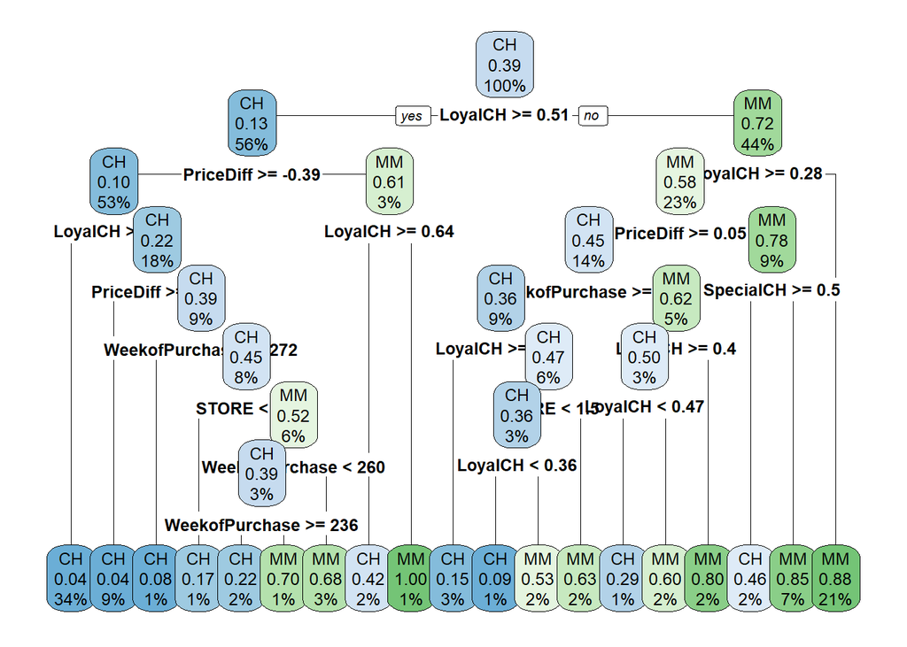

```r
rpart.plot(simple_tree_model_AUC[["finalModel"]], tweak=1.75)
```

### 1.4 Evaluate the final model on the test set. Is the AUC close to what we got via cross-validation?

Calculating AUC:

```r
## evaluating the classification tree model on test-set
test_prediction_probs <- predict.train(simple_tree_model,
                                        newdata = data_test,
                                        type = "prob") # obtaining probabilities instead of binary predictions

# drawing the ROC curve by using the built-in plot method:
simple_tree_prediction <- prediction(test_prediction_probs$MM,
                              data_test[["Purchase"]])

# calculating AUC = area under the curve -> the measure of predictive power
AUC <- performance(simple_tree_prediction, "auc")@y.values[[1]]
print(AUC)
```

```
## [1] 0.8843499
```

AUC stands for *Area under the curve*, it is practically the integral of ROC curve, the higher the value, the better the prediction is. It is a model independent way to assess the predictive performance of a model. In this case `AUC = 0.8843499` is very close to what we got via cross-validation and is actually slightly higher.

The ROC curve is a two-dimensional plot with false positive rate on the x axis and true positive rate on the y axis. It can be interpreted as displaying the true positive rates for any false positive rate. The higher the true positive rate, the better the model is.

The ROC curve of the model chosen in task 1.2 drawn by built-in function:

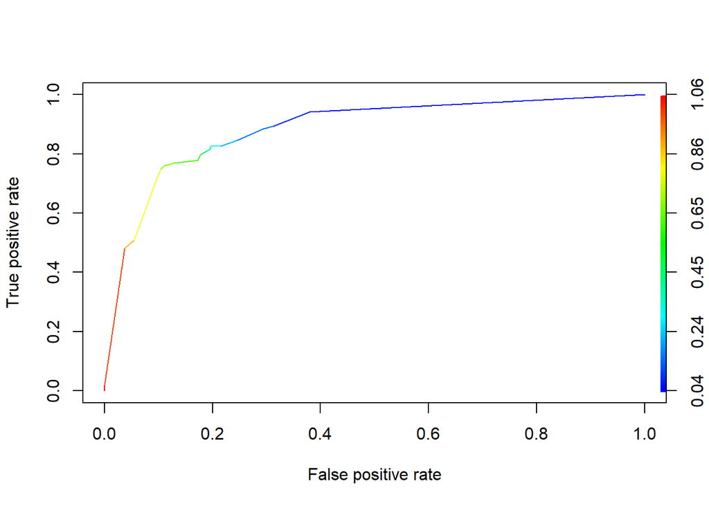

```r
## using the built-in plot method
plot(performance(simple_tree_prediction, "tpr", "fpr"), colorize=TRUE)
```

The ROC curve of the model chosen in task 1.2 drawn by `ggplot` package:

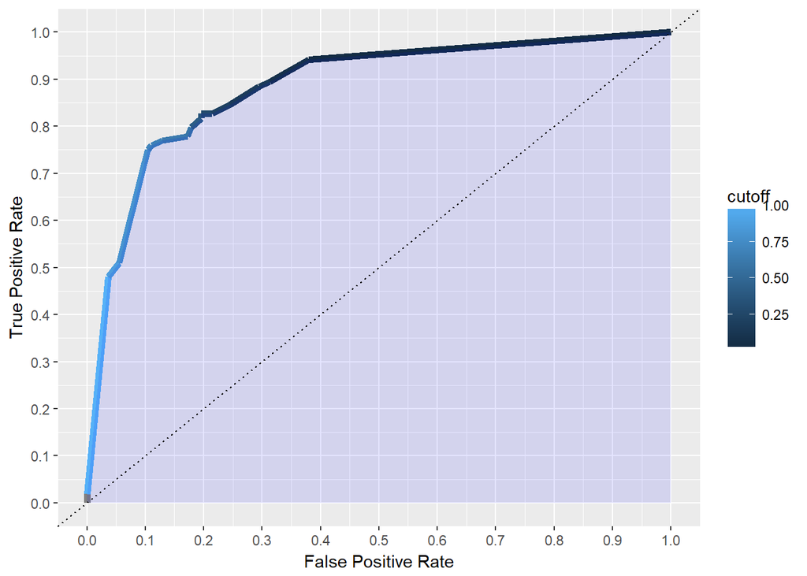

```r
simple_tree_perf <- performance(simple_tree_prediction, measure = "tpr", x.measure = "fpr")

simple_tree_roc_df <- data.table(
  model = "rpart",
  FPR = simple_tree_perf@x.values[[1]],
  TPR = simple_tree_perf@y.values[[1]],
  cutoff = simple_tree_perf@alpha.values[[1]] # cutoff is the treshold
)

ggplot(simple_tree_roc_df) +
  geom_line(aes(FPR, TPR, color = cutoff), size = 2) +
  geom_ribbon(aes(FPR, ymin = 0, ymax = TPR), fill = "blue", alpha = 0.1) +
  geom_abline(intercept = 0, slope = 1,  linetype = "dotted", col = "black") +
  scale_y_continuous(limits = c(0, 1), breaks = seq(0, 1, .1)) +
  scale_x_continuous(limits = c(0, 1), breaks = seq(0, 1, .1)) +
  xlab("False Positive Rate") + ylab("True Positive Rate")
```

Confusion matrix done on the test-set:

```r
test_prediction <- predict.train(simple_tree_model,
                                        newdata = data_test)
#test_prediction

test_truth <- data_test[["Purchase"]]
confusionMatrix(test_prediction, test_truth)
```

```
## Confusion Matrix and Statistics
##
##           Reference
## Prediction  CH  MM
##         CH 135  23
##         MM  28  81
##
##                Accuracy : 0.809
##                  95% CI : (0.7566, 0.8543)
##     No Information Rate : 0.6105
##     P-Value [Acc > NIR] : 2.3e-12
##
##                   Kappa : 0.6018
##  Mcnemar's Test P-Value : 0.5754
##
##             Sensitivity : 0.8282
##             Specificity : 0.7788
##          Pos Pred Value : 0.8544
##          Neg Pred Value : 0.7431
##              Prevalence : 0.6105
##          Detection Rate : 0.5056
##    Detection Prevalence : 0.5918
##       Balanced Accuracy : 0.8035
##
##        'Positive' Class : CH
##
```

## 2. Tree ensemble models

In this exercise for the same problem analyzed in Problem 1, we are investigating tree ensemble models and trying various tuning parameter combinations. At the end the best model is to be selected by using cross-validation but not considering the `oneSE` rule.

The models are built via 10-fold cross-validation repeated 3 times.

### 2.1 Random forest with 10 trees `rf_model_ntree_10`

The number of trees to build is not a tuning parameter in `caret`, the default value is 500. For the first try I set the number of trees to build to 10 (`ntree = 10`). The number of randomly chosen features to use when doing a split can be also set by `mtry`, first I am trying with 2, 3 and 5.

```r
train_control <- trainControl(method = "repeatedcv",
                              number = 10,
                              repeats = 3,
                              summaryFunction = twoClassSummary,
                              classProbs = TRUE)

set.seed(20180311)
rf_model_ntree_10 <- train(Purchase ~ .,
                  method = "rf",
                  data = data_train,
                  trControl = train_control,
                  tuneGrid = data.frame(mtry = c(2, 3, 5)),
                  ntree = 10,
                  importance = T, # to calculate variable importance measures
                  metric = "ROC")
rf_model_ntree_10
```

```
## Random Forest
##
## 803 samples
##  17 predictor
##   2 classes: 'CH', 'MM'
##
## No pre-processing
## Resampling: Cross-Validated (10 fold, repeated 3 times)
## Summary of sample sizes: 723, 723, 722, 723, 723, 722, ...
## Resampling results across tuning parameters:
##
##   mtry  ROC        Sens       Spec
##   2     0.8476859  0.8693878  0.6634073
##   3     0.8609029  0.8578231  0.7070565
##   5     0.8587777  0.8326531  0.7007056
##
## ROC was used to select the optimal model using the largest value.
## The final value used for the model was mtry = 3.
```

The model found `mtry = 3` to be the optimal parameter with `AUC = 0.8609029`.

### 2.2 Random forest with 500 trees `rf_model`

Now I am building a random forest with the default setting, with 500 trees and setting `mtry` to a sequence of numbers but still not setting it to 17.

```r
# random forest
set.seed(20180311)
rf_model <- train(Purchase ~ .,
                  method = "rf",
                  data = data_train,
                  trControl = train_control,
                  tuneGrid = data.frame(mtry = c(2, 3, 5, 8, 13)),
                  importance = T, # to calculate variable importance measures
                  metric = "ROC")
# random forest has two parameters: number of trees to build (default is 500) and number of features to randomly use (mtry)
# in this example we have 19 features, so running random forest with all the features is bagging (boostrap aggregating)
rf_model
```

```
## Random Forest
##
## 803 samples
##  17 predictor
##   2 classes: 'CH', 'MM'
##
## No pre-processing
## Resampling: Cross-Validated (10 fold, repeated 3 times)
## Summary of sample sizes: 723, 723, 722, 723, 723, 722, ...
## Resampling results across tuning parameters:
##
##   mtry  ROC        Sens       Spec
##    2    0.8779344  0.8761905  0.6921371
##    3    0.8817383  0.8625850  0.7114919
##    5    0.8827367  0.8598639  0.7231519
##    8    0.8804319  0.8476190  0.7178091
##   13    0.8802258  0.8333333  0.7327621
##
## ROC was used to select the optimal model using the largest value.
## The final value used for the model was mtry = 5.
```

### 2.3 Random forest with bagging `rf_model_bagging`

When setting `mtry` to the number of features available, it is called bagging, bootstrap aggregating.

```r
# random forest with bagging
set.seed(20180311)
rf_model_bagging <- train(Purchase ~ .,
                  method = "rf",
                  data = data_train,
                  trControl = train_control,
                  tuneGrid = data.frame(mtry = 17),
                  importance = T, # to calculate variable importance measures
                  metric = "ROC")
rf_model_bagging
```

```
## Random Forest
##
## 803 samples
##  17 predictor
##   2 classes: 'CH', 'MM'
##
## No pre-processing
## Resampling: Cross-Validated (10 fold, repeated 3 times)
## Summary of sample sizes: 723, 723, 722, 723, 723, 722, ...
## Resampling results:
##
##   ROC       Sens       Spec
##   0.881597  0.8265306  0.7400874
##
## Tuning parameter 'mtry' was held constant at a value of 17
```

The model with `mtry` set to 17 (using all variables) gave the result of `AUC = 0.881597`, it outperformed model `rf_model_ntree_10`, but did not beat model `rf_model`.

### 2.4 Gradient boosting machines `gbm_model`

We are also building many trees here, in that sense it is qutie similar to random forest. The difference between random forest and gradient boosting is that gradiant boosting machines do not necessarily need to be trees, they can be else, but this time it is done with trees. The way of combining trees is also different, because we are also looking at the residuals and trying to explain them. It works sequentally, meaning, that first we build a tree, compute the residuals, then build a model on residuals too, then repeat it, it is the sequence.

Shrinkage is also used by the lambda shrinkage parameter, which serves the purpose of regularization. It determines how much I am going take the model fitted on residuals into account.

This model can be very computationally extensive, it has many tuning parameters:

- number of trees to build,
- depth of trees to build,
- shrinkage parameter and
- minimum number of observations in a node.

```r
# gradient boosting machines
gbm_grid <- expand.grid(n.trees = c(100, 500, 1000), # number of trees to build
                        interaction.depth = c(2, 3, 5), # how large trees I want to use, the larger, the more complex individual trees I have
                        shrinkage = c(0.005, 0.01, 0.1), # the smaller the shrinkage, the less I take the model fitted to residuals into account
                        n.minobsinnode = c(5)) # a threshold for obs in a node

set.seed(20180311)
gbm_model <- train(Purchase ~ .,
                   method = "gbm",
                   data = data_train,
                   trControl = train_control,
                   tuneGrid = gbm_grid,
                   verbose = FALSE,
                   metric = "ROC"
                   )
gbm_model
```

```
## Stochastic Gradient Boosting
##
## 803 samples
##  17 predictor
##   2 classes: 'CH', 'MM'
##
## No pre-processing
## Resampling: Cross-Validated (10 fold, repeated 3 times)
## Summary of sample sizes: 723, 723, 722, 723, 723, 722, ...
## Resampling results across tuning parameters:
##
##   shrinkage  interaction.depth  n.trees  ROC        Sens       Spec
##   0.005      2                   100     0.8853426  0.8836735  0.6740591
##   0.005      2                   500     0.8969432  0.8619048  0.7538978
##   0.005      2                  1000     0.9017545  0.8687075  0.7646169
##   0.005      3                   100     0.8933403  0.9034014  0.6506384
##   0.005      3                   500     0.9020343  0.8659864  0.7657258
##   0.005      3                  1000     0.9045229  0.8653061  0.7656922
##   0.005      5                   100     0.8979784  0.9190476  0.6441868
##   0.005      5                   500     0.9042582  0.8653061  0.7603159
##   0.005      5                  1000     0.9031288  0.8632653  0.7614247
##   0.010      2                   100     0.8881316  0.8666667  0.7112567
##   0.010      2                   500     0.9014699  0.8666667  0.7624328
##   0.010      2                  1000     0.9028771  0.8687075  0.7667003
##   0.010      3                   100     0.8971541  0.8693878  0.7357863
##   0.010      3                   500     0.9036870  0.8632653  0.7646169
##   0.010      3                  1000     0.9031452  0.8659864  0.7614583
##   0.010      5                   100     0.9007591  0.8768707  0.7325941
##   0.010      5                   500     0.9033852  0.8632653  0.7655914
##   0.010      5                  1000     0.9009700  0.8537415  0.7592742
##   0.100      2                   100     0.9019314  0.8707483  0.7572581
##   0.100      2                   500     0.8937606  0.8564626  0.7486895
##   0.100      2                  1000     0.8851180  0.8482993  0.7454973
##   0.100      3                   100     0.9003809  0.8639456  0.7614247
##   0.100      3                   500     0.8853649  0.8455782  0.7400874
##   0.100      3                  1000     0.8774135  0.8367347  0.7368952
##   0.100      5                   100     0.8970351  0.8571429  0.7530578
##   0.100      5                   500     0.8777715  0.8374150  0.7444556
##   0.100      5                  1000     0.8691831  0.8312925  0.7422043
##
## Tuning parameter 'n.minobsinnode' was held constant at a value of 5
## ROC was used to select the optimal model using the largest value.
## The final values used for the model were n.trees = 1000,
##  interaction.depth = 3, shrinkage = 0.005 and n.minobsinnode = 5.
```

The model found `interaction.depth = 3`, `shrinkage = 0.005` and `n.trees = 1000` to be the optimal parameters, kept `n.minobsinnode = 5` constant and yielded `AUC = 0.9045229`, it is better than the previous results achieved by random forest.

### 2.5 Gradient boosting machines `gbm_model_2`

There is another parameter that we could tiune, `bag.fraction` parameter. By setting `bag.fraction` to any number between 0 and 1, we can set what fraction of the (training) data we want to use, randomly selected, to build each tree. This can introduce some randomness in the model. Now I am building a model with `bag.fraction` set to 0.8, keeping the other variables, `interaction.depth = 3`, `shrinkage = 0.005`, `n.minobsinnode = 5` and `n.trees = 1000` constant. These parameters have been found the best by model `gbm_model`.

```r
gbm_grid_2 <- data.frame(n.trees = c(1000),
                         interaction.depth = c(3),
                         shrinkage = c(0.005),
                         n.minobsinnode = c(5))

gbm_model_2 <- train(Purchase ~ .,
                   method = "gbm",
                   data = data_train,
                   trControl = train_control,
                   tuneGrid = gbm_grid_2,
                   bag.fraction = 0.8,
                   verbose = FALSE, # gbm by default prints too much output
                   metric = "ROC"
                   )
gbm_model_2
```

```
## Stochastic Gradient Boosting
##
## 803 samples
##  17 predictor
##   2 classes: 'CH', 'MM'
##
## No pre-processing
## Resampling: Cross-Validated (10 fold, repeated 3 times)
## Summary of sample sizes: 722, 722, 723, 723, 723, 723, ...
## Resampling results:
##
##   ROC        Sens      Spec
##   0.9040158  0.862585  0.7656922
##
## Tuning parameter 'n.trees' was held constant at a value of 1000
##  3
## Tuning parameter 'shrinkage' was held constant at a value of
##  0.005
## Tuning parameter 'n.minobsinnode' was held constant at a value of 5
```

The model yielded `AUC = 0.9040158`, which is only slightly behind model `gbm_model`.

### 2.6 XGBoost `xgboost_model`

It is a gradient boosting algorithm (using more tricks and regularization). The original gradient boosting algorithm has been further mastered. It is very robust and can be faster and accessed via `caret`. Tuning parameters are basically the same but have different names, such as:

- `nrounds` - number of trees to build,
- `max_depth` - same `interaction.depth`,
- `eta` - shrinkage parameter,
- `gamma` - complexity parameter,
- `min_child_weight` - minimum number of observation in final nodes.

```r
# xgboost
xgbGrid <- expand.grid(nrounds = c(500, 1000), # number of trees = n.trees
                       max_depth = c(2, 3, 5), # interaction.depth
                       eta = c(0.01, 0.05), # shrinkage parameter
                       gamma = 0, # complexity parameter
                       colsample_bytree = c(0.5, 0.7),
                       min_child_weight = 1, # number of obs in final nodes
                       subsample = c(0.5)) # similar to bag parameter to GBM,

set.seed(20180311)
xgboost_model <- train(Purchase ~ .,
                       method = "xgbTree",
                       data = data_train,
                       trControl = train_control,
                       tuneGrid = xgbGrid)
xgboost_model
```

```
## eXtreme Gradient Boosting
##
## 803 samples
##  17 predictor
##   2 classes: 'CH', 'MM'
##
## No pre-processing
## Resampling: Cross-Validated (10 fold, repeated 3 times)
## Summary of sample sizes: 723, 723, 722, 723, 723, 722, ...
## Resampling results across tuning parameters:
##
##   eta   max_depth  colsample_bytree  nrounds  ROC        Sens
##   0.01  2          0.5                500     0.9007766  0.8721088
##   0.01  2          0.5               1000     0.9028188  0.8721088
##   0.01  2          0.7                500     0.9012320  0.8659864
##   0.01  2          0.7               1000     0.9027941  0.8707483
##   0.01  3          0.5                500     0.9031658  0.8721088
##   0.01  3          0.5               1000     0.9024746  0.8612245
##   0.01  3          0.7                500     0.9042877  0.8707483
##   0.01  3          0.7               1000     0.9028195  0.8605442
##   0.01  5          0.5                500     0.8994024  0.8653061
##   0.01  5          0.5               1000     0.8976098  0.8537415
##   0.01  5          0.7                500     0.9012429  0.8564626
##   0.01  5          0.7               1000     0.8972086  0.8523810
##   0.05  2          0.5                500     0.9008185  0.8639456
##   0.05  2          0.5               1000     0.8959338  0.8557823
##   0.05  2          0.7                500     0.9008459  0.8591837
##   0.05  2          0.7               1000     0.8951363  0.8537415
##   0.05  3          0.5                500     0.8945342  0.8551020
##   0.05  3          0.5               1000     0.8862406  0.8530612
##   0.05  3          0.7                500     0.8940644  0.8517007
##   0.05  3          0.7               1000     0.8846791  0.8482993
##   0.05  5          0.5                500     0.8855178  0.8476190
##   0.05  5          0.5               1000     0.8739511  0.8414966
##   0.05  5          0.7                500     0.8834379  0.8482993
##   0.05  5          0.7               1000     0.8700924  0.8380952
##   Spec
##   0.7624664
##   0.7634745
##   0.7677419
```

[output cut: 16 more lines]

```
##   0.7486895
##   0.7497984
##   0.7391129
##   0.7445565
##   0.7411962
##
## Tuning parameter 'gamma' was held constant at a value of 0
##
## Tuning parameter 'min_child_weight' was held constant at a value of
##  1
## Tuning parameter 'subsample' was held constant at a value of 0.5
## ROC was used to select the optimal model using the largest value.
## The final values used for the model were nrounds = 500, max_depth = 3,
##  eta = 0.01, gamma = 0, colsample_bytree = 0.7, min_child_weight = 1
##  and subsample = 0.5.
```

The model yielded `AUC = 0.9042877`, which is slightly behind model `gbm_model`.

### 2.7 Compare different models with the resamples function (make sure to set the same seed before model training for all 3 models). Is any of these giving significantly different predictive power than the others?

```r
resamples_object <- resamples(list("rpart_AUC" = simple_tree_model_AUC,
                                   "rpart_oneSE" = simple_tree_model,
                                   "rf_ntree_10" = rf_model_ntree_10,
                                   "rf" = rf_model,
                                   "rf_bagging" = rf_model_bagging,
                                   "gbm" = gbm_model,
                                   "gbm_2" = gbm_model_2,
                                   "xgboost" = xgboost_model))
summary(resamples_object)
```

```
##
## Call:
## summary.resamples(object = resamples_object)
##
## Models: rpart_AUC, rpart_oneSE, rf_ntree_10, rf, rf_bagging, gbm, gbm_2, xgboost
## Number of resamples: 30
##
## ROC
##                  Min.   1st Qu.    Median      Mean   3rd Qu.      Max.
## rpart_AUC   0.7495063 0.8528637 0.8788677 0.8767261 0.8998724 0.9601403
## rpart_oneSE 0.7455563 0.8544221 0.8760698 0.8711982 0.8963211 0.9528061
## rf_ntree_10 0.7678571 0.8306452 0.8610362 0.8609029 0.8943384 0.9394133
## rf          0.7684949 0.8615043 0.8938446 0.8827367 0.9153226 0.9617347
## rf_bagging  0.7691327 0.8605605 0.8862893 0.8815970 0.9133476 0.9464286
## gbm         0.8220663 0.8816656 0.9081633 0.9045229 0.9338381 0.9601403
## gbm_2       0.8150099 0.8875905 0.9045425 0.9040158 0.9246215 0.9751276
## xgboost     0.8220663 0.8806781 0.9060648 0.9042877 0.9333443 0.9614158
##             NA's
## rpart_AUC      0
## rpart_oneSE    0
## rf_ntree_10    0
## rf             0
## rf_bagging     0
## gbm            0
## gbm_2          0
## xgboost        0
##
## Sens
##                  Min.   1st Qu.    Median      Mean   3rd Qu.      Max.
## rpart_AUC   0.7551020 0.8010204 0.8367347 0.8428571 0.8979592 0.9183673
## rpart_oneSE 0.7142857 0.8163265 0.8469388 0.8380952 0.8775510 0.9183673
## rf_ntree_10 0.7551020 0.8214286 0.8571429 0.8578231 0.8979592 0.9591837
## rf          0.7551020 0.8214286 0.8571429 0.8598639 0.8979592 0.9591837
## rf_bagging  0.7346939 0.7959184 0.8367347 0.8265306 0.8571429 0.9387755
## gbm         0.7346939 0.8214286 0.8775510 0.8653061 0.9132653 0.9387755
## gbm_2       0.7551020 0.8163265 0.8571429 0.8625850 0.9132653 0.9591837
## xgboost     0.7959184 0.8214286 0.8775510 0.8707483 0.8979592 0.9387755
##             NA's
## rpart_AUC      0
## rpart_oneSE    0
```

[output cut: 11 more lines]

```
## rf_ntree_10 0.5483871 0.6451613 0.7096774 0.7070565 0.7734375 0.8387097
## rf          0.5483871 0.6774194 0.7303427 0.7231519 0.7794859 0.8709677
## rf_bagging  0.6129032 0.6930444 0.7419355 0.7400874 0.7741935 0.8750000
## gbm         0.6451613 0.7096774 0.7741935 0.7656922 0.8109879 0.9062500
## gbm_2       0.6250000 0.7419355 0.7741935 0.7656922 0.8064516 0.9032258
## xgboost     0.6451613 0.7187500 0.7620968 0.7677755 0.8001512 0.9062500
##             NA's
## rpart_AUC      0
## rpart_oneSE    0
## rf_ntree_10    0
## rf             0
## rf_bagging     0
## gbm            0
## gbm_2          0
## xgboost        0
```

### 2.7 Choose the best model and plot ROC curve for the best model on the test set. Calculate and interpret AUC.

The best model by looking at the highest mean of ROC is `gbm_model`.

Calculating AUC:

```r
## evaluating the classification tree model on test-set
test_prediction_probs <- predict.train(gbm_model,
                                        newdata = data_test,
                                        type = "prob") # obtaining probabilities instead of binary predictions

# drawing the ROC curve by using the built-in plot method:
best_model_prediction <- prediction(test_prediction_probs$MM,
                              data_test[["Purchase"]])

# calculating AUC = area under the curve -> the measure of predictive power
AUC <- performance(best_model_prediction, "auc")@y.values[[1]]
print(AUC)
```

```
## [1] 0.8864736
```

In this case the AUC is `0.8864736`.

The ROC curve drawn by built-in function:

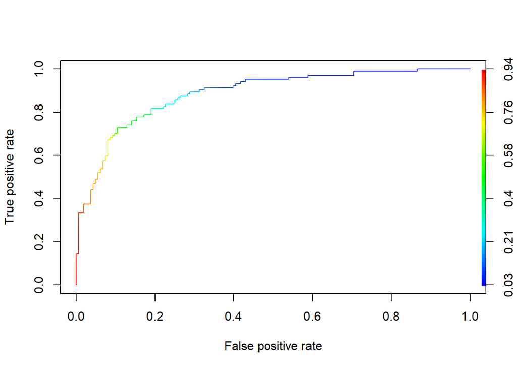

```r
## using the built-in plot method
plot(performance(best_model_prediction, "tpr", "fpr"), colorize=TRUE)
```

The ROC curve drawn by `ggplot` package:

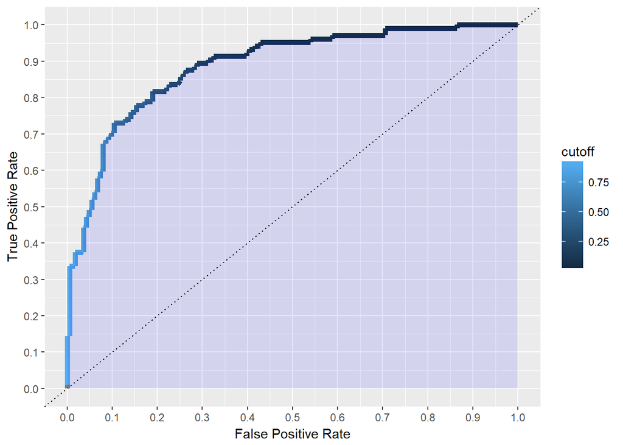

```r
best_model_perf <- performance(best_model_prediction, measure = "tpr", x.measure = "fpr")

best_model_roc_df <- data.table(
  model = "gbm_model",
  FPR = best_model_perf@x.values[[1]],
  TPR = best_model_perf@y.values[[1]],
  cutoff = best_model_perf@alpha.values[[1]] # cutoff is the treshold
)

ggplot(best_model_roc_df) +
  geom_line(aes(FPR, TPR, color = cutoff), size = 2) +
  geom_ribbon(aes(FPR, ymin = 0, ymax = TPR), fill = "blue", alpha = 0.1) +
  geom_abline(intercept = 0, slope = 1,  linetype = "dotted", col = "black") +
  scale_y_continuous(limits = c(0, 1), breaks = seq(0, 1, .1)) +
  scale_x_continuous(limits = c(0, 1), breaks = seq(0, 1, .1)) +
  xlab("False Positive Rate") + ylab("True Positive Rate")
```

### 2.8 Inspect variable importance plots for the 3 models. Are similar variables found to be the most important for the 3 models?

Variable importance measures can help to see which features contribute the most to the predictive power of our models. Please find a variable importance plot for `rf_model_ntree_10` model below:

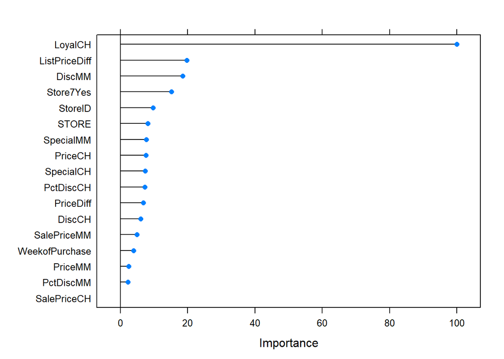

```r
plot(varImp(rf_model_ntree_10))
```

Variable importance plot for `rf_model` model below:

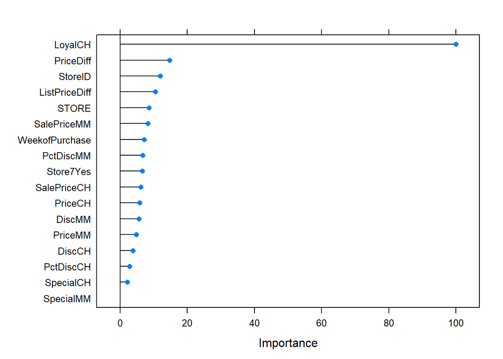

```r
plot(varImp(rf_model))
```

Variable importance plot for `rf_model_bagging` model below:

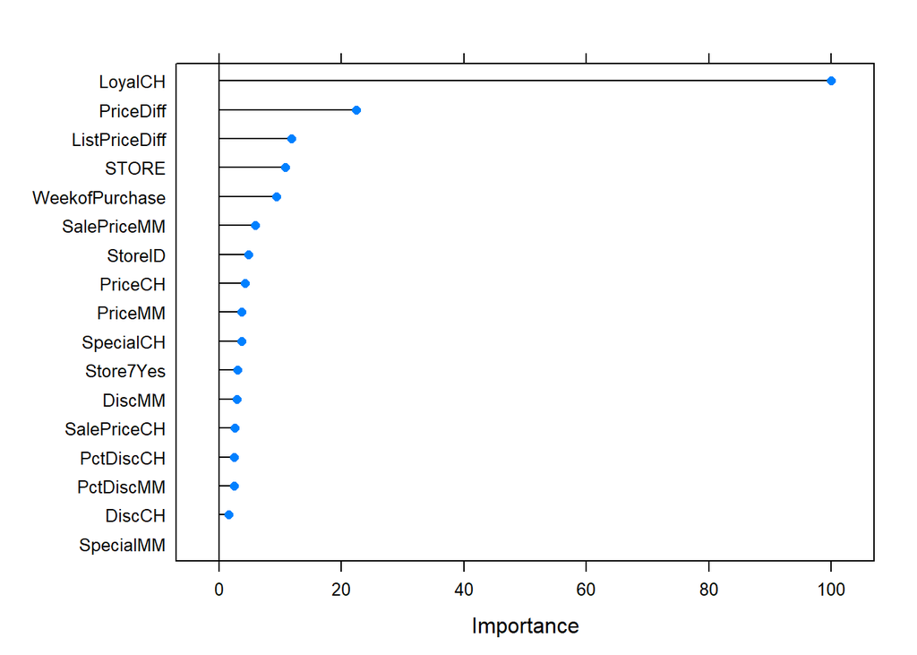

```r
plot(varImp(rf_model_bagging))
```

Variable importance plot for `gbm_model` model below:

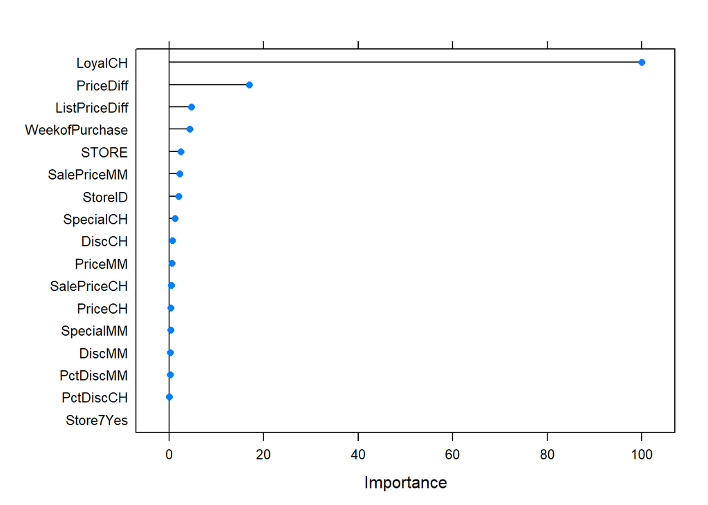

```r
plot(varImp(gbm_model))
```

Variable importance plot for `xgboost_model` model below:

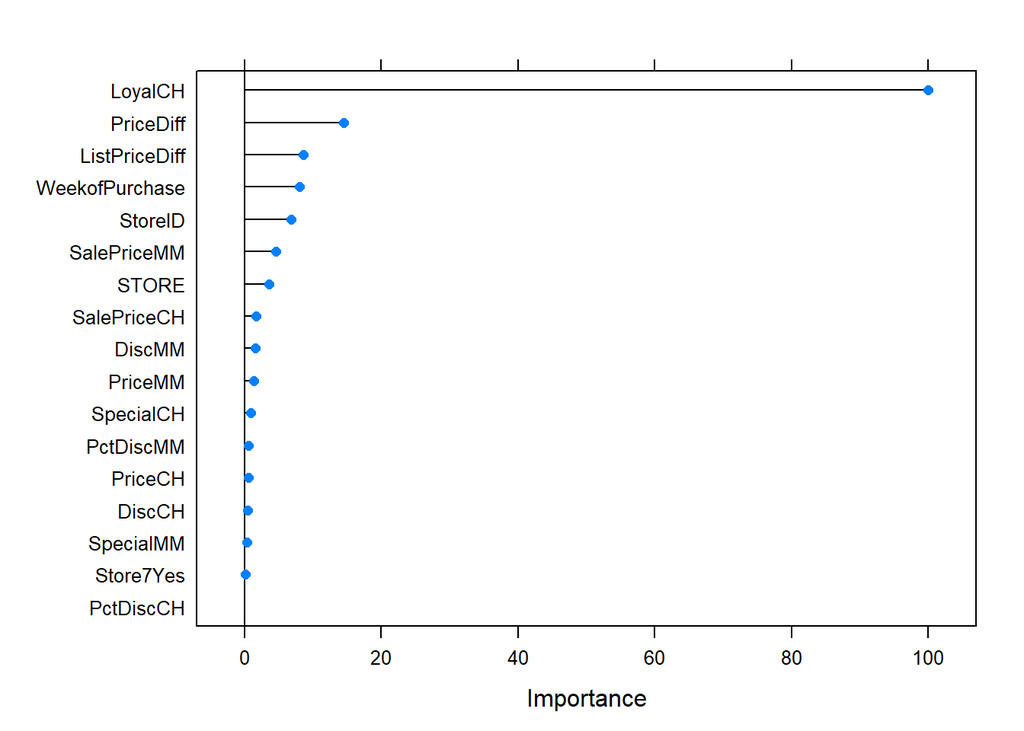

```r
plot(varImp(xgboost_model))
```

**Different random forest models:**

Random forest found `LoyalCH` to be the most important variable in case of all three models. But the second and third most important variables are not the same across them. The reason for it is that when running random forest we intentionally constrain the algorithm to randomly consider only a limited number of features. Thus, by chance, we can have different variable improtance plots.

**Bagging, Gradient boosting machine and XGboost:**

Bagging, gradient boosting machine and `XGboost` turned out to have the same three variables as the most important ones: `LoyalCH`, `PriceDiff` and `ListPriceDiff`, in this order in all three cases. (In case of bagging we let the algorithm to consider all the features.)

## 3. Variable importance profiles

Using the Hitters dataset and predicting `log_salary`.

I have loaded the data set and removed the `Salary` column, as we already have a `log_salary` column and that is what we would predict with the model. 59 NAs have also been dropped.

```r
data <- data.table(Hitters)
data <- data[!is.na(Salary)]
data[, log_salary := log(Salary)]
data[, Salary := NULL]
```

### 3.1 train two random forest models: one with mtry = 2 and another with mtry = 10 (use the whole dataset and don’t use cross-validation). Inspect variable importance profiles. What do you see in terms of how important the first few variables are relative to each other?

I have named the models `rf_model_mtry_2` and `rf_model_mtry_10` according to the specification of how many features to use.

#### 3.1.1 Random forest with `mtry` set to 2

```r
train_control <- trainControl()

set.seed(20180311)
rf_model_mtry_2 <- train(log_salary ~ .,
                  method = "rf",
                  data = data,
                  trControl = train_control,
                  tuneGrid = data.frame(mtry = 2),
                  #ntree = 10,
                  importance = T
                  ) # to calculate variable importance measures
rf_model_mtry_2
```

```
## Random Forest
##
## 263 samples
##  19 predictor
##
## No pre-processing
## Resampling: Bootstrapped (25 reps)
## Summary of sample sizes: 263, 263, 263, 263, 263, 263, ...
## Resampling results:
##
##   RMSE       Rsquared   MAE
##   0.4474523  0.7519712  0.3103612
##
## Tuning parameter 'mtry' was held constant at a value of 2
```

#### 3.1.2 Random forest with `mtry` set to 10

```r
set.seed(20180311)
rf_model_mtry_10 <- train(log_salary ~ .,
                  method = "rf",
                  data = data,
                  trControl = train_control,
                  tuneGrid = data.frame(mtry = 10),
                  #ntree = 10,
                  importance = T) # to calculate variable importance measures
rf_model_mtry_10
```

```
## Random Forest
##
## 263 samples
##  19 predictor
##
## No pre-processing
## Resampling: Bootstrapped (25 reps)
## Summary of sample sizes: 263, 263, 263, 263, 263, 263, ...
## Resampling results:
##
##   RMSE       Rsquared  MAE
##   0.4556573  0.740394  0.3158069
##
## Tuning parameter 'mtry' was held constant at a value of 10
```

#### 3.1.3 Variable importance plots:

Variable importance plot for `rf_model_mtry_2`:

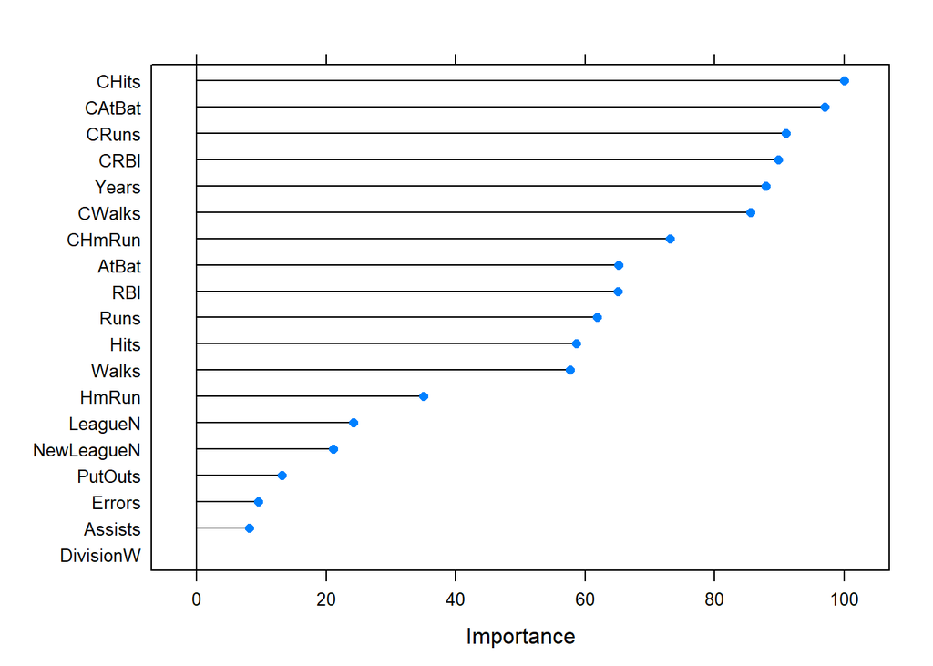

```r
plot(varImp(rf_model_mtry_2))
```

Variable importance plot for `rf_model_mtry_10`:

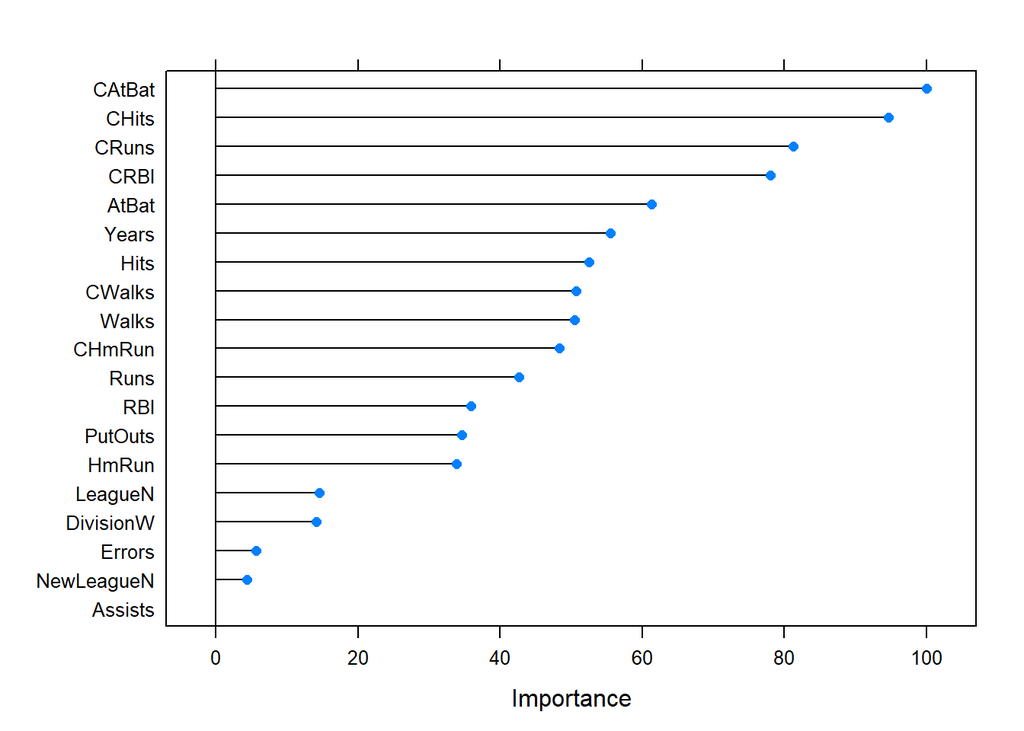

```r
plot(varImp(rf_model_mtry_10))
```

We can see that the third and fourth variables are the same for both models (`CRuns` and `CRBI`), but that is not true for the first and second variables. `CHits` is the first most important variable for model `rf_model_mtry_2`, but only second for `rf_model_mtry_10`, and vica versa for `CAtBat` variable.

In addition to that the third and fourth variables seem to be realtively less important compared to the first two variables in case of model `rf_model_mtry_10`. The otehr variables are also relatively less important compared to the first most improtant variables.

### 3.2 One of them is more extreme in terms of how the most important and the next ones relate to each other. Give an intuitive explanation how mtry relates to relative importance of variables in random forest models.

By setting `mtry` we can constrain how many features the algorithm can randomly consider when doing a split. When constraining it to a low number, say 2, the algorithm has a lower chance to pick the most relevant feature of the data set, so other, less relevant features would have a higher chance to contribute to the final prediction power. In case of setting `mtry` to 10, it is more likely that the most relevant features can be chosen for the split, so they can contribute more and doing so, less relevant features will contribute relatively less.

### 3.3 In the same vein, estimate two gbm models and set `bag.fraction` to 0.1 first and to 0.9 in the second. The `tuneGrid` should consist of the same values for the two models (a dataframe with one row):

- n.trees = 500
- interaction.depth = 5
- shrinkage = 0.1
- n.minobsinnode = 5

#### 3.3.1 Gradient boosting machine with `bag.fraction` set to 0.1

```r
# gradient boosting machines
gbm_grid <- expand.grid(n.trees = 500, # number of trees to build
                        interaction.depth = 5, # how large trees I want to use, the larger, the more complex individual trees I have
                        shrinkage = 0.1, # the smaller the shrinkage, the less I take the model fitted to residuals into account
                        #bag.fraction = 0.1,
                        n.minobsinnode = 5) # a threshold for obs in a node

set.seed(20180311)
gbm_model <- train(log_salary ~ .,
                   method = "gbm",
                   data = data,
                   trControl = train_control,
                   tuneGrid = gbm_grid,
                   bag.fraction = 0.1,
                   verbose = FALSE
                   )
gbm_model
```

```
## Stochastic Gradient Boosting
##
## 263 samples
##  19 predictor
##
## No pre-processing
## Resampling: Bootstrapped (25 reps)
## Summary of sample sizes: 263, 263, 263, 263, 263, 263, ...
## Resampling results:
##
##   RMSE       Rsquared  MAE
##   0.5225189  0.673042  0.375418
##
## Tuning parameter 'n.trees' was held constant at a value of 500
##  5
## Tuning parameter 'shrinkage' was held constant at a value of 0.1
##
## Tuning parameter 'n.minobsinnode' was held constant at a value of 5
```

#### 3.3.2 Gradient boosting machine with `bag.fraction` set to 0.9

```r
# gradient boosting machines
set.seed(20180311)
gbm_model_2 <- train(log_salary ~ .,
                   method = "gbm",
                   data = data,
                   trControl = train_control,
                   tuneGrid = gbm_grid,
                   bag.fraction = 0.9,
                   verbose = FALSE
                   )
gbm_model_2
```

```
## Stochastic Gradient Boosting
##
## 263 samples
##  19 predictor
##
## No pre-processing
## Resampling: Bootstrapped (25 reps)
## Summary of sample sizes: 263, 263, 263, 263, 263, 263, ...
## Resampling results:
##
##   RMSE       Rsquared   MAE
##   0.4948068  0.6993256  0.3484794
##
## Tuning parameter 'n.trees' was held constant at a value of 500
##  5
## Tuning parameter 'shrinkage' was held constant at a value of 0.1
##
## Tuning parameter 'n.minobsinnode' was held constant at a value of 5
```

#### 3.3.3 Variable importance plots

Compare variable importance plots for the two models. What is the meaning of bag.fraction? Based on this, why is one variable importance profile more extreme than the other?

Variable importance plot for model `gbm_model`

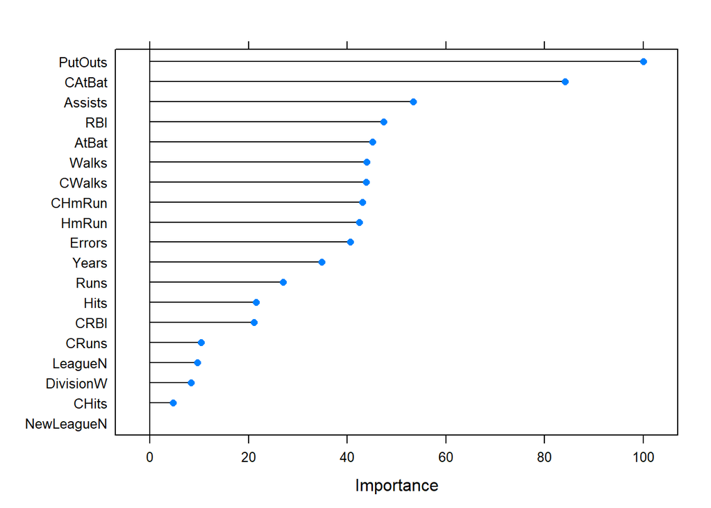

```r
plot(varImp(gbm_model))
```

Variable importance plot for model `gbm_model_2`

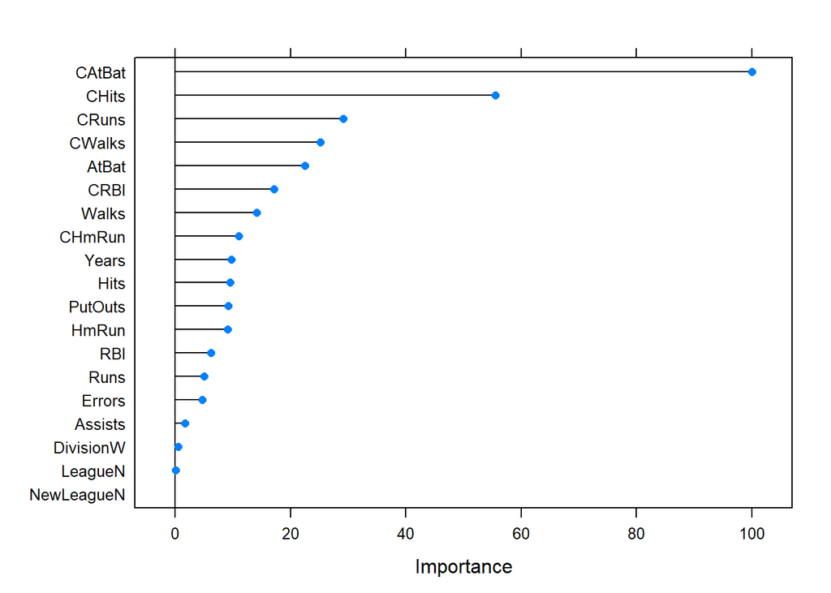

```r
plot(varImp(gbm_model_2))
```

By setting `bag.fraction` to any number between 0 and 1, we can set what fraction of the (training) data we want to use, randomly selected, to build each tree. This can introduce some randomness in the model.

When setting `bag.fraction` to 0.9, because of using almost 100% of the data, we can expect similar results to model `rf_model_mtry_10`. The algorithm had a higher chance of choosing from the relevant variables. But when setting `bag.fraction` to 0.1, teh chance of picking up observations where the above seen relevant variables are not that relevant, is higher, so by chance, other variables have a higher likelyhood of contributing more to the prediction.